# Informe #2

2025-10-07

# 1 Introducción

La **tuberculosis (TB)** sigue siendo una de las enfermedades infecciosas más relevantes a nivel global, con un impacto sostenido en la salud pública a pesar de los avances en diagnóstico y tratamiento. Una proporción significativa de la población mundial vive con una infección latente por *Mycobacterium tuberculosis* (LTBI), lo que implica la presencia de la bacteria sin manifestación activa de la enfermedad, pero con riesgo potencial de desarrollarla en el futuro. Comprender la magnitud y evolución de esta infección es fundamental para orientar las políticas de prevención y control que promueve la Organización Mundial de la Salud (OMS).

El presente análisis se basa en las estimaciones publicadas por la OMS dentro del *Global Tuberculosis Report 2024*, específicamente en el apartado sobre **infección latente por tuberculosis (LTBI) en contactos domiciliarios**, que representa a uno de los grupos poblacionales con mayor vulnerabilidad frente a la transmisión de la enfermedad. Este tipo de información permite observar la situación global de la infección y los avances alcanzados en la detección y contención de la tuberculosis durante las últimas décadas.

En este contexto, el análisis busca responder a la siguiente pregunta:  
**¿Cómo ha variado la prevalencia estimada de infección latente por tuberculosis (LTBI) en contactos domiciliarios a nivel mundial entre los años 2000 y 2024, y qué regiones presentan los mayores cambios en sus estimaciones durante este período?**

**Fuente:** https://www.who.int/teams/global-programme-on-tuberculosis-and-lung-health/data

# 2 Preparación de los datos

## 2.1 Carga de datos

Librerías utilizadas:

```r
library(readr)
library(Amelia)
library(ggplot2)
library(dplyr)
library(tibble)
library(knitr)
library(mice)
library(patchwork)
library(gridExtra)
library(reshape2)
library(viridis)
```

En primer lugar, se carga la base de datos.

```r
dataset <- read_csv("LTBI_estimates_2025-10-08.csv")
```

## 2.2 Vista preliminar

Para dar un primer vistazo al dataframe, se hace uso de la función **head()** para ver sus primeros **10 registros**:

```r
head(dataset, 10)
```

```
## # A tibble: 10 × 25
##    country     iso2  iso3  iso_numeric g_whoregion  year source_hh     e_hh_size
##    <chr>       <chr> <chr> <chr>       <chr>       <dbl> <chr>             <dbl>
##  1 Afghanistan AF    AFG   004         EMR          2015 DHS; 2015-10…      8.04
##  2 Afghanistan AF    AFG   004         EMR          2016 DHS; 2015-10…      8.04
##  3 Afghanistan AF    AFG   004         EMR          2017 DHS; 2015-10…      8.04
##  4 Afghanistan AF    AFG   004         EMR          2018 DHS; 2015-10…      8.04
##  5 Afghanistan AF    AFG   004         EMR          2019 DHS; 2015-10…      8.04
##  6 Afghanistan AF    AFG   004         EMR          2020 DHS; 2015-10…      8.04
##  7 Afghanistan AF    AFG   004         EMR          2021 DHS; 2015-10…      8.04
##  8 Afghanistan AF    AFG   004         EMR          2022 DHS; 2015-10…      8.04
##  9 Afghanistan AF    AFG   004         EMR          2023 DHS; 2015-10…      8.04
## 10 Albania     AL    ALB   008         EUR          2015 DHS; 2017-01…      3.3
## # ℹ 17 more variables: prevtx_data_available <dbl>, newinc_con_prevtx <dbl>,
## #   newinc_con04_prevtx <dbl>, ptsurvey_newinc <dbl>,
## #   ptsurvey_newinc_con04_prevtx <dbl>, e_hh_contacts <dbl>,
## #   e_hh_contacts_lo <dbl>, e_hh_contacts_hi <dbl>,
## #   e_prevtx_hh_contacts_pct <dbl>, e_prevtx_hh_contacts_pct_lo <dbl>,
## #   e_prevtx_hh_contacts_pct_hi <dbl>, e_prevtx_eligible <dbl>,
## #   e_prevtx_eligible_lo <dbl>, e_prevtx_eligible_hi <dbl>, …
```

Haciendo uso de la función **glimpse()** del paquete **dplyr**, es posible conocer el número total de **filas** y **columnas** presentes en la base de datos, así como conocer los nombres de cada **variable**.

```r
glimpse(dataset)
```

```
## Rows: 1,710
## Columns: 25
## $ country                      <chr> "Afghanistan", "Afghanistan", "Afghanista…
## $ iso2                         <chr> "AF", "AF", "AF", "AF", "AF", "AF", "AF",…
## $ iso3                         <chr> "AFG", "AFG", "AFG", "AFG", "AFG", "AFG",…
## $ iso_numeric                  <chr> "004", "004", "004", "004", "004", "004",…
## $ g_whoregion                  <chr> "EMR", "EMR", "EMR", "EMR", "EMR", "EMR",…
## $ year                         <dbl> 2015, 2016, 2017, 2018, 2019, 2020, 2021,…
## $ source_hh                    <chr> "DHS; 2015-10-19", "DHS; 2015-10-19", "DH…
## $ e_hh_size                    <dbl> 8.04, 8.04, 8.04, 8.04, 8.04, 8.04, 8.04,…
## $ prevtx_data_available        <dbl> 60, 60, 60, 60, 60, 60, 60, 60, 1, 60, 60…
## $ newinc_con_prevtx            <dbl> NA, NA, NA, 22467, 24701, 23336, 25360, 3…
## $ newinc_con04_prevtx          <dbl> 10164, 15417, 24666, 22467, 24701, 23336,…
## $ ptsurvey_newinc              <dbl> NA, NA, NA, NA, NA, NA, NA, NA, NA, NA, N…
## $ ptsurvey_newinc_con04_prevtx <dbl> NA, NA, NA, NA, NA, NA, NA, NA, NA, NA, N…
## $ e_hh_contacts                <dbl> 120000, 130000, 140000, 140000, 170000, 1…
## $ e_hh_contacts_lo             <dbl> 110000, 130000, 130000, 140000, 160000, 1…
## $ e_hh_contacts_hi             <dbl> 120000, 130000, 140000, 150000, 170000, 1…
## $ e_prevtx_hh_contacts_pct     <dbl> 8.70, 12.00, 35.00, 16.00, 15.00, 15.00, …
## $ e_prevtx_hh_contacts_pct_lo  <dbl> 8.50, 12.00, 34.00, 15.00, 15.00, 15.00, …
## $ e_prevtx_hh_contacts_pct_hi  <dbl> 8.90, 12.00, 35.00, 16.00, 15.00, 16.00, …
## $ e_prevtx_eligible            <dbl> 22000.0, 24000.0, 25000.0, 26000.0, 30000…
## $ e_prevtx_eligible_lo         <dbl> 20000.0, 22000.0, 23000.0, 24000.0, 27000…
## $ e_prevtx_eligible_hi         <dbl> 24000.0, 26000.0, 28000.0, 29000.0, 33000…
## $ e_prevtx_kids_pct            <dbl> 46.0, 64.0, 97.0, 85.0, 82.0, 85.0, 86.0,…
## $ e_prevtx_kids_pct_lo         <dbl> 42.0, 58.0, 89.0, 78.0, 76.0, 78.0, 79.0,…
## $ e_prevtx_kids_pct_hi         <dbl> 51, 70, 100, 93, 90, 93, 94, 100, 100, 15…
```

Este dataset contiene **25 variables** diferentes, que se definen y clasifican según sus tipos en la siguiente tabla:

```r
tabla_variables <- tribble(
  ~"Nombre de la variable", ~"Descripción", ~"Tipo de variable",
  "country", "Nombre del país o territorio reportado por la OMS.", "Cualitativa - Nominal",
  "iso2", "Código ISO de dos letras del país.", "Cualitativa - Nominal",
  "iso3", "Código ISO de tres letras del país.", "Cualitativa - Nominal",
  "iso_numeric", "Código numérico del país según el estándar ISO.", "Cualitativa - Nominal",
  "g_whoregion", "Región geográfica de la OMS a la que pertenece el país.", "Cualitativa - Nominal",
  "year", "Año de referencia de la estimación de infección latente por TB.", "Cuantitativa - Discreta",
  "source_hh", "Fuente de los datos de contactos domiciliarios utilizada en la estimación.", "Cualitativa - Nominal",
  "e_hh_size", "Tamaño medio de los hogares.", "Cuantitativa - Continua",
  "prevtx_data_available", "Indicador de disponibilidad de datos previos de tratamiento (1 = disponible, 0 = no disponible).", "Cuantitativa - Discreta",
  "newinc_con_prevtx", "Número estimado de nuevos casos de TB en contactos domiciliarios con historial previo de tratamiento.", "Cuantitativa - Discreta",
  "newinc_con04_prevtx", "Número estimado de nuevos casos de TB en contactos menores de 5 años con historial previo de tratamiento.", "Cuantitativa - Discreta",
  "ptsurvey_newinc", "Número estimado de nuevos casos en encuestas poblacionales de TB activa.", "Cuantitativa - Discreta",
  "ptsurvey_newinc_con04_prevtx", "Estimación de nuevos casos en encuestas poblacionales para menores de 5 años con historial previo de tratamiento.", "Cuantitativa - Discreta",
  "e_hh_contacts", "Número estimado de contactos domiciliarios incluidos en la modelización.", "Cuantitativa - Discreta",
  "e_hh_contacts_lo", "Límite inferior del intervalo de incertidumbre para el número de contactos domiciliarios.", "Cuantitativa - Continua",
  "e_hh_contacts_hi", "Límite superior del intervalo de incertidumbre para el número de contactos domiciliarios.", "Cuantitativa - Continua",
  "e_prevtx_hh_contacts_pct", "Porcentaje estimado de contactos domiciliarios con tratamiento previo para TB.", "Cuantitativa - Continua",
  "e_prevtx_hh_contacts_pct_lo", "Límite inferior del intervalo de incertidumbre del porcentaje de contactos con tratamiento previo.", "Cuantitativa - Continua",
  "e_prevtx_hh_contacts_pct_hi", "Límite superior del intervalo de incertidumbre del porcentaje de contactos con tratamiento previo.", "Cuantitativa - Continua",
  "e_prevtx_eligible", "Número estimado de personas elegibles para profilaxis o tratamiento preventivo de TB.", "Cuantitativa - Discreta",
  "e_prevtx_eligible_lo", "Límite inferior del intervalo de incertidumbre para los elegibles a tratamiento preventivo.", "Cuantitativa - Continua",
  "e_prevtx_eligible_hi", "Límite superior del intervalo de incertidumbre para los elegibles a tratamiento preventivo.", "Cuantitativa - Continua",
  "e_prevtx_kids_pct", "Porcentaje de niños elegibles dentro de los contactos domiciliarios.", "Cuantitativa - Continua",
  "e_prevtx_kids_pct_lo", "Límite inferior del intervalo de incertidumbre del porcentaje de niños elegibles.", "Cuantitativa - Continua",
  "e_prevtx_kids_pct_hi", "Límite superior del intervalo de incertidumbre del porcentaje de niños elegibles.", "Cuantitativa - Continua"
)

kable(tabla_variables)
```

[output not shown]

Con el fin de dar foco a resolver la **pregunta** propuesta al inicio del **EDA**, se tienen en cuenta sólo las variables **year**, **g_whoregion**, **e_prevtx_hh_contacts_pct**, **e_prevtx_hh_contacts_pct_lo**, **e_prevtx_hh_contacts_pct_hi**, **e_prevtx_kids_pct** y **e_prevtx_eligible**. Estas variables fueron seleccionadas por ser las que mejor representan la evolución temporal, la distribución regional y la magnitud estimada de la infección latente por tuberculosis (LTBI), permitiendo analizar tanto su comportamiento global como las diferencias entre regiones.

Ahora, se construirá un **dataframe** sólo con estas variables para mayor comodidad a la hora de trabajar en el resto del análisis. A su vez, se usa nuevamente **glimpse()** para desplegar un resumen del mismo.

```r
data <- dataset %>%
  select(
    year,
    g_whoregion,
    e_prevtx_hh_contacts_pct,
    e_prevtx_hh_contacts_pct_lo,
    e_prevtx_hh_contacts_pct_hi,
    e_prevtx_kids_pct,
    e_prevtx_eligible
  ) %>%

  rename(
    anio = year,
    region_OMS = g_whoregion,
    prevalencia_contactos = e_prevtx_hh_contacts_pct,
    prevalencia_inferior = e_prevtx_hh_contacts_pct_lo,
    prevalencia_superior = e_prevtx_hh_contacts_pct_hi,
    porcentaje_ninos = e_prevtx_kids_pct,
    elegibles_tratamiento = e_prevtx_eligible
  )

glimpse(data)
```

```
## Rows: 1,710
## Columns: 7
## $ anio                  <dbl> 2015, 2016, 2017, 2018, 2019, 2020, 2021, 2022, …
## $ region_OMS            <chr> "EMR", "EMR", "EMR", "EMR", "EMR", "EMR", "EMR",…
## $ prevalencia_contactos <dbl> 8.70, 12.00, 35.00, 16.00, 15.00, 15.00, 15.00, …
## $ prevalencia_inferior  <dbl> 8.50, 12.00, 34.00, 15.00, 15.00, 15.00, 15.00, …
## $ prevalencia_superior  <dbl> 8.90, 12.00, 35.00, 16.00, 15.00, 16.00, 16.00, …
## $ porcentaje_ninos      <dbl> 46.0, 64.0, 97.0, 85.0, 82.0, 85.0, 86.0, 100.0,…
## $ elegibles_tratamiento <dbl> 22000.0, 24000.0, 25000.0, 26000.0, 30000.0, 280…
```

## 2.3 Detección de valores faltantes

Con el fin de verificar el porcentaje de valores **NA** presentes en el dataframe, se generará un **missingness map** haciendo uso de la función **missma()** del paquete **Amelia**.

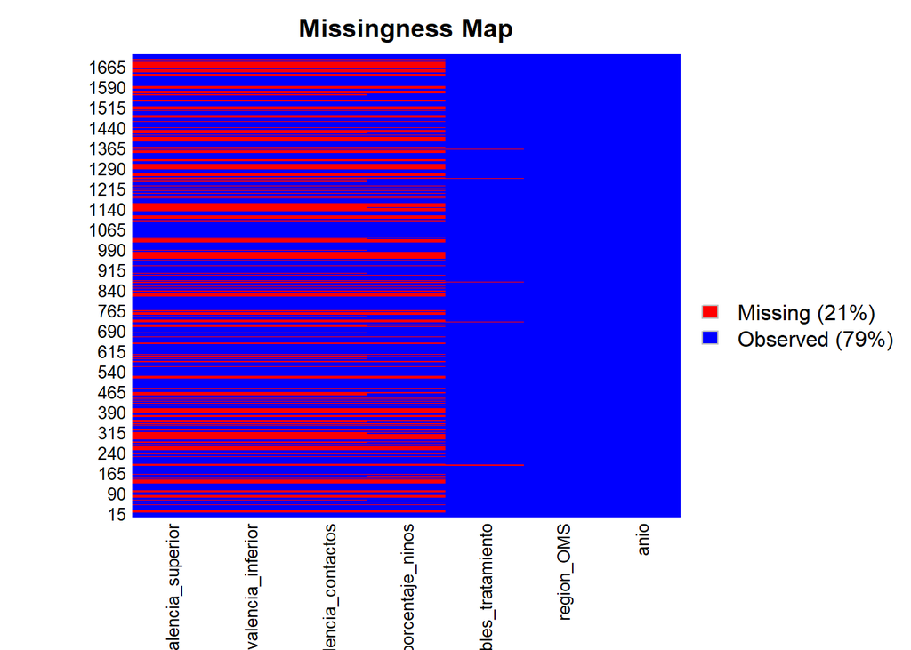

```r
missmap(data, col = c("red", "blue"), legend = TRUE)
```

Como se puede observar, el dataframe tiene un **21%** de **datos faltantes**. Sin embargo, antes de imputar, es necesario analizar el porcentaje correspondiente a cada variable; por lo que se crean la siguiente tabla y el siguiente gráfico de barras:

```r
porcentaje_na <- sapply(data, function(x) sum(is.na(x)) / length(x) * 100)

tabla_na <- data.frame(
  Variable = names(porcentaje_na),
  Porcentaje_NA = round(porcentaje_na, 2)
)

tabla_na <- tabla_na[order(-tabla_na$Porcentaje_NA), ]
print(tabla_na)
```

```
##                                    Variable Porcentaje_NA
## prevalencia_contactos prevalencia_contactos         37.43
## prevalencia_inferior   prevalencia_inferior         37.43
## prevalencia_superior   prevalencia_superior         37.43
## porcentaje_ninos           porcentaje_ninos         35.15
## elegibles_tratamiento elegibles_tratamiento          0.82
## anio                                   anio          0.00
## region_OMS                       region_OMS          0.00
```

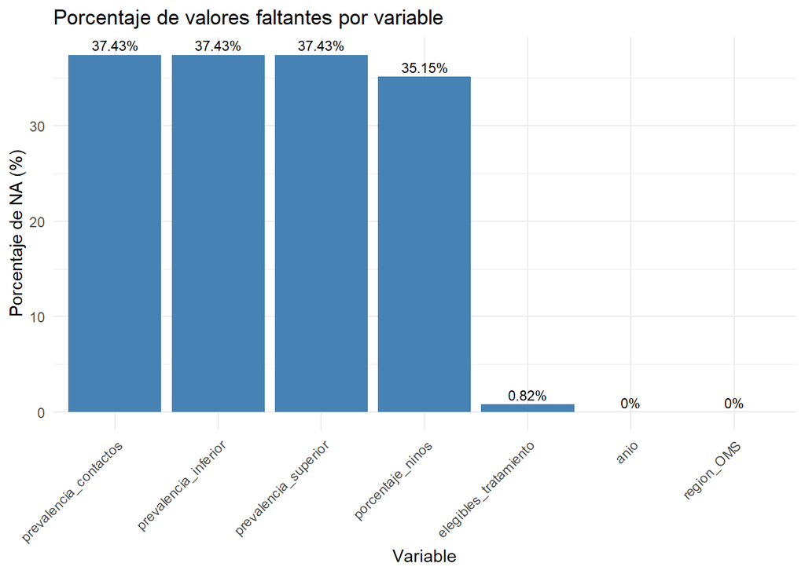

```r
ggplot(tabla_na, aes(x = reorder(Variable, -Porcentaje_NA), y = Porcentaje_NA)) +
  geom_bar(stat = "identity", fill = "steelblue") +
  geom_text(aes(label = paste0(Porcentaje_NA, "%")), vjust = -0.4, size = 3) +
  labs(
    title = "Porcentaje de valores faltantes por variable",
    x = "Variable",
    y = "Porcentaje de NA (%)"
  ) +
  theme_minimal() +
  theme(axis.text.x = element_text(angle = 45, hjust = 1))
```

Ahora, se clasificarán según su **tipo de ausencia**.

```r
clasificacion_ausencia <- data.frame(
  Variable = c(
    "prevalencia_contactos",
    "prevalencia_inferior",
    "prevalencia_superior",
    "porcentaje_ninos",
    "elegibles_tratamiento",
    "anio",
    "region_OMS"
  ),
  Tipo_ausencia = c(
    "MAR (Missing At Random)",
    "MAR (Missing At Random)",
    "MAR (Missing At Random)",
    "MNAR (Missing Not At Random)",
    "MCAR (Missing Completely At Random)",
    "Sin NA",
    "Sin NA"
  ),
  Justificacion = c(
    "Los faltantes se concentran en ciertas regiones o años, probablemente por ausencia de mediciones locales.",
    "Presenta el mismo patrón que 'prevalencia_contactos', así que los faltantes dependen de esa misma causa.",
    "Se comporta igual que las anteriores; las ausencias parecen venir del mismo proceso de no registro.",
    "Los datos que faltan están ligados a zonas donde no se hacen pruebas en menores, lo que puede sesgar los valores.",
    "Tiene pocos NA, distribuidos al azar; seguramente se deben a errores puntuales de reporte.",
    "Variable completa, sin valores faltantes.",
    "Variable completa, sin valores faltantes."
  )
)

kable(clasificacion_ausencia, caption = "Tipos de ausencia de datos por variable")
```

Tipos de ausencia de datos por variable

| Variable | Tipo_ausencia | Justificacion |
| --- | --- | --- |
| prevalencia_contactos | MAR (Missing At Random) | Los faltantes se concentran en ciertas regiones o años, probablemente por ausencia de mediciones locales. |
| prevalencia_inferior | MAR (Missing At Random) | Presenta el mismo patrón que ‘prevalencia_contactos’, así que los faltantes dependen de esa misma causa. |
| prevalencia_superior | MAR (Missing At Random) | Se comporta igual que las anteriores; las ausencias parecen venir del mismo proceso de no registro. |
| porcentaje_ninos | MNAR (Missing Not At Random) | Los datos que faltan están ligados a zonas donde no se hacen pruebas en menores, lo que puede sesgar los valores. |
| elegibles_tratamiento | MCAR (Missing Completely At Random) | Tiene pocos NA, distribuidos al azar; seguramente se deben a errores puntuales de reporte. |
| anio | Sin NA | Variable completa, sin valores faltantes. |
| region_OMS | Sin NA | Variable completa, sin valores faltantes. |

## 2.4 Imputación de valores faltantes

Luego de identificar el tipo de ausencia de datos en cada variable, se procede con la imputación.

### 2.4.1 Imputación de variables MAR

Las variables **prevalencia_contactos**, **prevalencia_inferior** y **prevalencia_superior** fueron clasificadas como MAR (Missing At Random). Esto significa que los valores faltantes no son completamente aleatorios, sino que dependen de otras variables observadas, como el **año** o la **región de la OMS**.

Por esa razón, se decidió imputarlas usando la **mediana por grupo (año y región)**. Esto permite mantener la coherencia entre países y periodos, evitando que la imputación afecte las diferencias entre zonas.

```r
mar_imputados <- data

grupos <- group_by(mar_imputados, region_OMS, anio)

mar_imputados <- mutate(grupos,
  prevalencia_contactos = ifelse(is.na(prevalencia_contactos),
                                 median(prevalencia_contactos, na.rm = TRUE),
                                 prevalencia_contactos),
  prevalencia_inferior = ifelse(is.na(prevalencia_inferior),
                                median(prevalencia_inferior, na.rm = TRUE),
                                prevalencia_inferior),
  prevalencia_superior = ifelse(is.na(prevalencia_superior),
                                median(prevalencia_superior, na.rm = TRUE),
                                prevalencia_superior)
)

mar_imputados <- ungroup(mar_imputados)
```

### 2.4.2 Imputación de variable MCAR

La variable **elegibles_tratamiento** fue clasificada como MCAR (Missing Completely At Random),  
ya que los valores faltantes son pocos (menos del 1%) y no muestran patrón alguno. En estos casos, lo más razonable es imputar usando la **mediana global**, ya que la ausencia es completamente aleatoria y no depende de ningún otro factor.

```r
mcar_imputados <- data

mediana_elegibles <- median(mcar_imputados$elegibles_tratamiento, na.rm = TRUE)

mcar_imputados$elegibles_tratamiento[
  is.na(mcar_imputados$elegibles_tratamiento)
] <- mediana_elegibles
```

### 2.4.3 Imputación de variable MNAR

La variable **porcentaje_ninos** se clasificó como MNAR (Missing Not At Random).  
Esto significa que los faltantes probablemente dependen del propio valor no observado;  
por ejemplo, regiones con baja cobertura en menores o sin programas de detección infantil.

En estos casos, imputar con una media o mediana puede introducir sesgo,  
así que se optó por una **imputación por regresión múltiple** usando el método **MICE**.  
Este enfoque aprovecha la información del resto de variables numéricas para estimar los valores más probables.

```r
mnar_imputados <- data

imputacion_mnar <- mice(
  mnar_imputados[, c("porcentaje_ninos",
                    "prevalencia_contactos",
                    "prevalencia_inferior",
                    "prevalencia_superior",
                    "elegibles_tratamiento")],
  m = 1,
  method = "norm.predict",
  seed = 123
)
mnar_imputados$porcentaje_ninos <- complete(imputacion_mnar)$porcentaje_ninos
```

## 2.5 Evaluación de la imputación

En esta sección, en primer lugar se genera un **nuevo dataframe** llamado **data_imputado**, con todas las imputaciones realizadas. Esto se hace, con el fin de poder compararlo con el dataframe **original**.

```r
data_imputado <- data

data_imputado$prevalencia_contactos <- mar_imputados$prevalencia_contactos
data_imputado$prevalencia_inferior  <- mar_imputados$prevalencia_inferior
data_imputado$prevalencia_superior  <- mar_imputados$prevalencia_superior

data_imputado$elegibles_tratamiento <- mcar_imputados$elegibles_tratamiento

data_imputado$porcentaje_ninos <- mnar_imputados$porcentaje_ninos

str(data_imputado)
```

```
## tibble [1,710 × 7] (S3: tbl_df/tbl/data.frame)
##  $ anio                 : num [1:1710] 2015 2016 2017 2018 2019 ...
##  $ region_OMS           : chr [1:1710] "EMR" "EMR" "EMR" "EMR" ...
##  $ prevalencia_contactos: num [1:1710] 8.7 12 35 16 15 15 15 19 19 0.23 ...
##  $ prevalencia_inferior : num [1:1710] 8.5 12 34 15 15 15 15 18 19 0.22 ...
##  $ prevalencia_superior : num [1:1710] 8.9 12 35 16 15 16 16 19 19 0.23 ...
##  $ porcentaje_ninos     : num [1:1710] 46 64 97 85 82 85 86 100 100 9.5 ...
##  $ elegibles_tratamiento: num [1:1710] 22000 24000 25000 26000 30000 28000 29000 30000 29000 10 ...
```

### 2.5.1 Missingness Map

Ahora, se genera un nuevo **missingness map** con el dataframe recién creado-

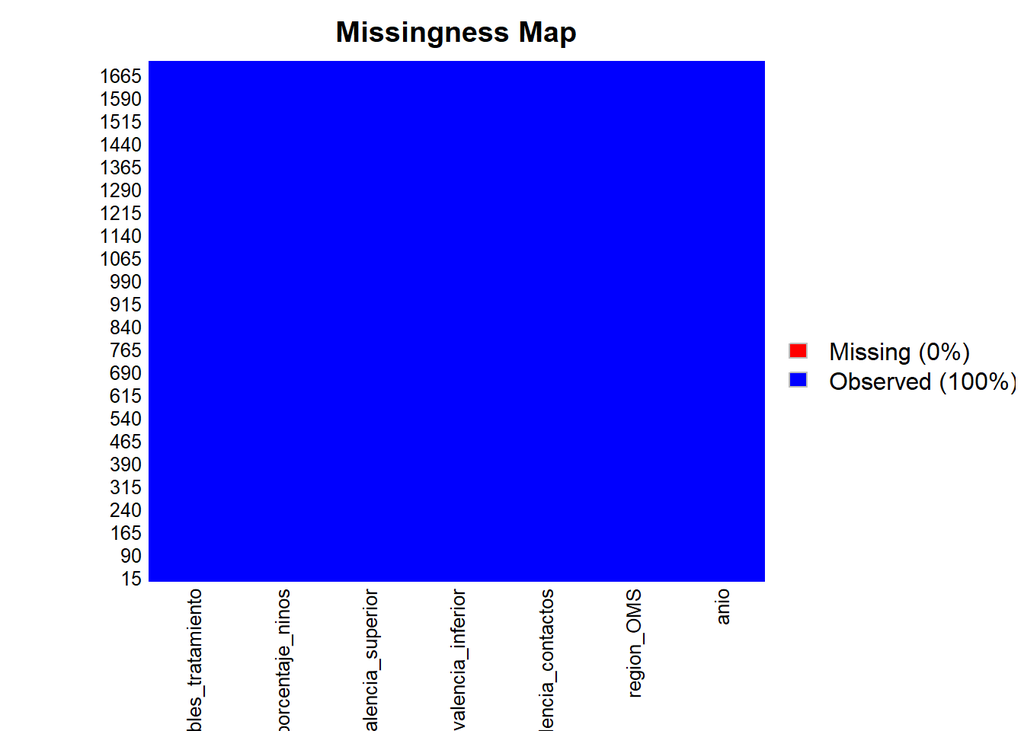

```r
missmap(data_imputado, col = c("red", "blue"), legend = TRUE)
```

El gráfico obtenido arroja un **0%** de valores **NA**, por lo que en una primera instancia, se puede considerar exitoso el proceso de imputación. Sin embargo, aún es necesario verificar que las distribuciones se mantengan iguales.

### 2.5.2 Histogramas

A continuación, se construyen varios **histogramas** comparativos, con el fin de obtener una representación visual de las distribuciones antes y después de imputar.

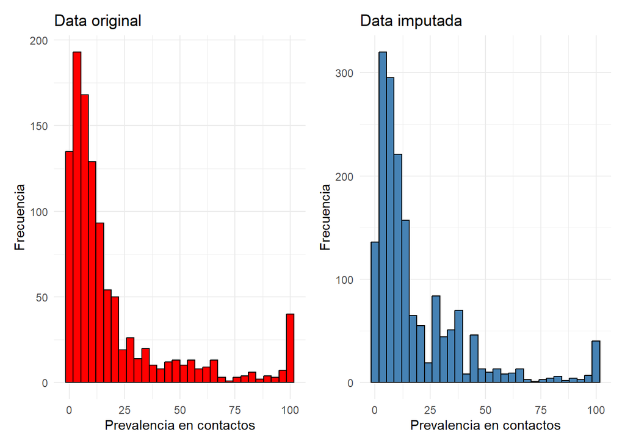

```r
g1 <- ggplot(data, aes(x = prevalencia_contactos)) +
  geom_histogram(fill = "red", color = "black", bins = 30) +
  ggtitle("Data original") +
  xlab("Prevalencia en contactos") +
  ylab("Frecuencia") +
  theme_minimal()

g2 <- ggplot(data_imputado, aes(x = prevalencia_contactos)) +
  geom_histogram(fill = "steelblue", color = "black", bins = 30) +
  ggtitle("Data imputada") +
  xlab("Prevalencia en contactos") +
  ylab("Frecuencia") +
  theme_minimal()


g1 + g2
```

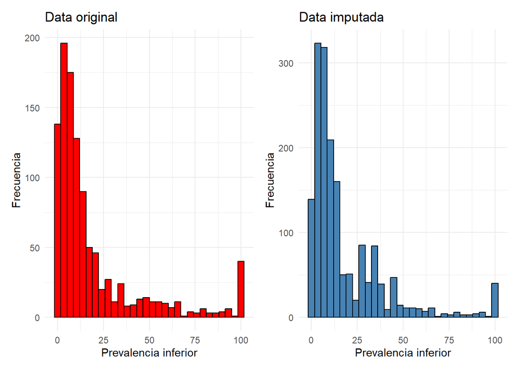

```r
g3 <- ggplot(data, aes(x = prevalencia_inferior)) +
  geom_histogram(fill = "red", color = "black", bins = 30) +
  ggtitle("Data original") +
  xlab("Prevalencia inferior") +
  ylab("Frecuencia") +
  theme_minimal()

g4 <- ggplot(data_imputado, aes(x = prevalencia_inferior)) +
  geom_histogram(fill = "steelblue", color = "black", bins = 30) +
  ggtitle("Data imputada") +
  xlab("Prevalencia inferior") +
  ylab("Frecuencia") +
  theme_minimal()

g3 + g4
```

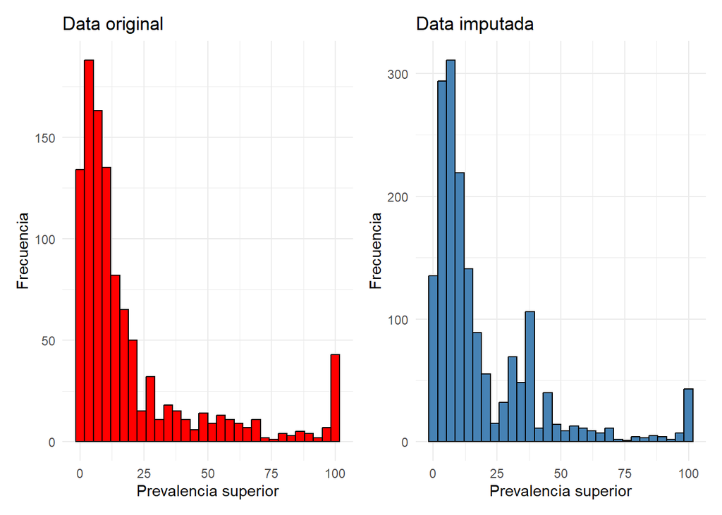

```r
g5 <- ggplot(data, aes(x = prevalencia_superior)) +
  geom_histogram(fill = "red", color = "black", bins = 30) +
  ggtitle("Data original") +
  xlab("Prevalencia superior") +
  ylab("Frecuencia") +
  theme_minimal()

g6 <- ggplot(data_imputado, aes(x = prevalencia_superior)) +
  geom_histogram(fill = "steelblue", color = "black", bins = 30) +
  ggtitle("Data imputada") +
  xlab("Prevalencia superior") +
  ylab("Frecuencia") +
  theme_minimal()

g5 + g6
```

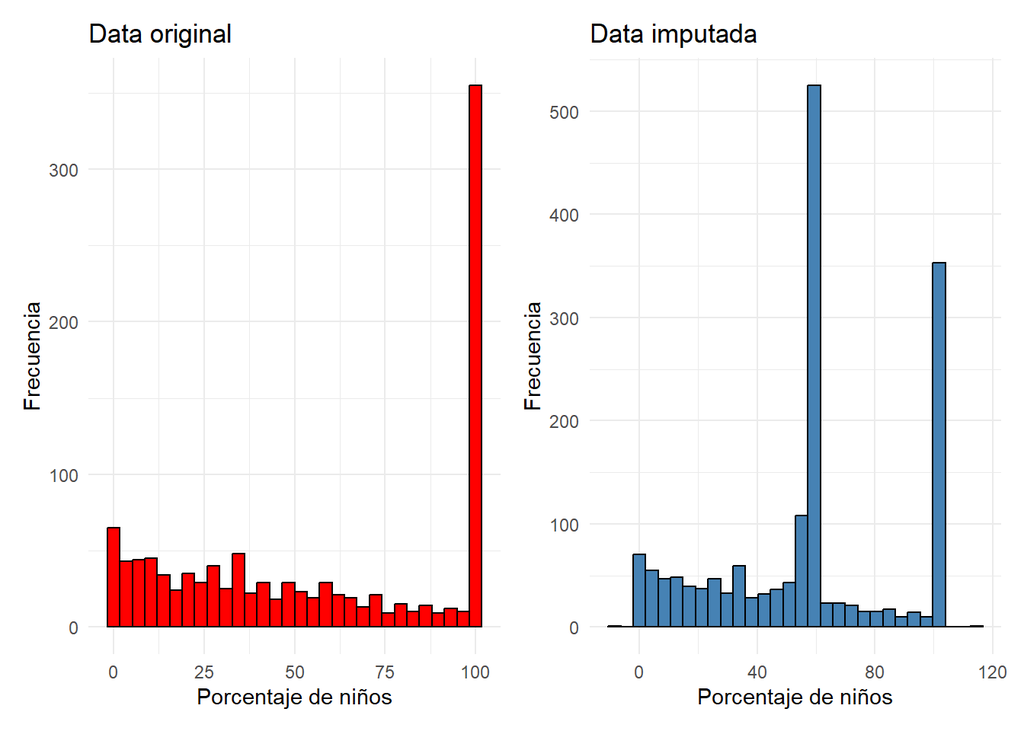

```r
g7 <- ggplot(data, aes(x = porcentaje_ninos)) +
  geom_histogram(fill = "red", color = "black", bins = 30) +
  ggtitle("Data original") +
  xlab("Porcentaje de niños") +
  ylab("Frecuencia") +
  theme_minimal()

g8 <- ggplot(data_imputado, aes(x = porcentaje_ninos)) +
  geom_histogram(fill = "steelblue", color = "black", bins = 30) +
  ggtitle("Data imputada") +
  xlab("Porcentaje de niños") +
  ylab("Frecuencia") +
  theme_minimal()

g7 + g8
```

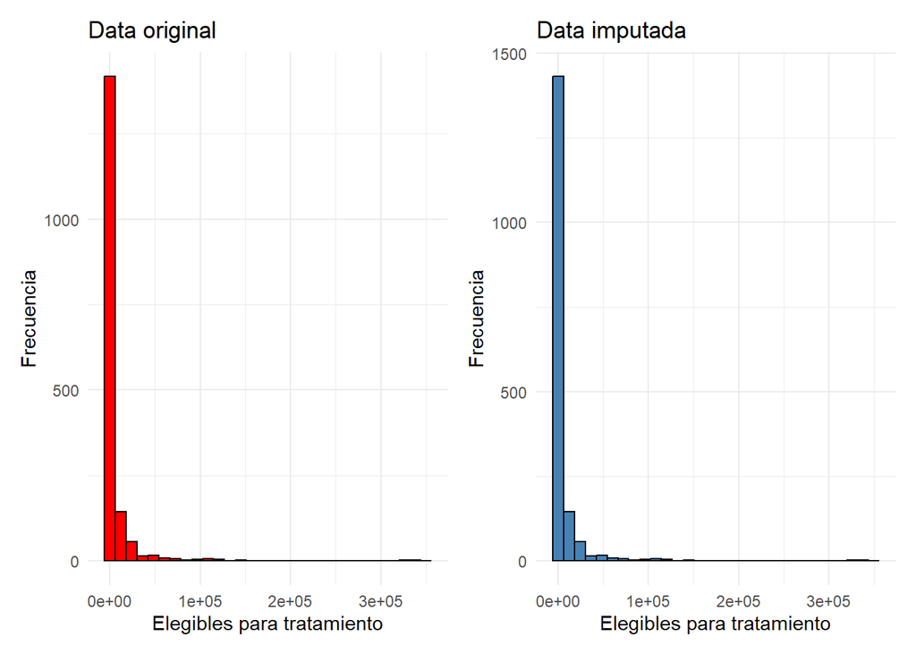

```r
g9 <- ggplot(data, aes(x = elegibles_tratamiento)) +
  geom_histogram(fill = "red", color = "black", bins = 30) +
  ggtitle("Data original") +
  xlab("Elegibles para tratamiento") +
  ylab("Frecuencia") +
  theme_minimal()

g10 <- ggplot(data_imputado, aes(x = elegibles_tratamiento)) +
  geom_histogram(fill = "steelblue", color = "black", bins = 30) +
  ggtitle("Data imputada") +
  xlab("Elegibles para tratamiento") +
  ylab("Frecuencia") +
  theme_minimal()

g9 + g10
```

### 2.5.3 Pruebas de normalidad

```r
vars_imputadas <- c("prevalencia_contactos",
                    "prevalencia_inferior",
                    "prevalencia_superior",
                    "porcentaje_ninos",
                    "elegibles_tratamiento")

resultados_shapiro <- data.frame(
  Variable = character(),
  W_original = numeric(),
  p_original = numeric(),
  W_imputado = numeric(),
  p_imputado = numeric(),
  Clasificacion = character()
)

for (v in vars_imputadas) {
  test_orig <- shapiro.test(data[[v]])
  test_imp <- shapiro.test(data_imputado[[v]])

  clasif <- ifelse(test_orig$p.value > 0.05 & test_imp$p.value > 0.05,
                   "Normal (p > 0.05)",
                   "No normal (p ≤ 0.05)")

  resultados_shapiro <- rbind(resultados_shapiro,
                              data.frame(
                                Variable = v,
                                W_original = round(test_orig$statistic, 4),
                                p_original = round(test_orig$p.value, 4),
                                W_imputado = round(test_imp$statistic, 4),
                                p_imputado = round(test_imp$p.value, 4),
                                Clasificacion = clasif))
}

kable(resultados_shapiro, caption = "Prueba de normalidad (Shapiro–Wilk) en datos originales e imputados")
```

Prueba de normalidad (Shapiro–Wilk) en datos originales e imputados

|  | Variable | W_original | p_original | W_imputado | p_imputado | Clasificacion |
| --- | --- | --- | --- | --- | --- | --- |
| W | prevalencia_contactos | 0.7005 | 0 | 0.7359 | 0 | No normal (p ≤ 0.05) |
| W1 | prevalencia_inferior | 0.6974 | 0 | 0.7314 | 0 | No normal (p ≤ 0.05) |
| W2 | prevalencia_superior | 0.7044 | 0 | 0.7409 | 0 | No normal (p ≤ 0.05) |
| W3 | porcentaje_ninos | 0.8592 | 0 | 0.9079 | 0 | No normal (p ≤ 0.05) |
| W4 | elegibles_tratamiento | 0.2435 | 0 | 0.2423 | 0 | No normal (p ≤ 0.05) |

Como los **p-values** obtenidos tras aplicar el test de **Shapiro-Wilk** son **menores que 0.05**, por lo que se afirma que ninguna de ellas sigue una distribución **normal**

### 2.5.4 ¿Se conservan o se distorsionan las distribuciones teóricamente?

```r
vars_no_normales <- c("prevalencia_contactos",
                      "prevalencia_inferior",
                      "prevalencia_superior",
                      "porcentaje_ninos",
                      "elegibles_tratamiento")

resultados_no_normales <- data.frame(
  Variable = character(),
  KS_p = numeric(),
  Mann_Whitney_p = numeric(),
  Conclusion = character()
)

for (v in vars_no_normales) {
  ks_p <- ks.test(data[[v]], data_imputado[[v]])$p.value
  mw_p <- wilcox.test(data[[v]], data_imputado[[v]])$p.value

  conclusion <- ifelse(ks_p > 0.05 & mw_p > 0.05,
                       " Preserva la distribución y el centro",
                       " Posible distorsión tras imputación")

  resultados_no_normales <- rbind(resultados_no_normales,
                                  data.frame(
                                    Variable = v,
                                    KS_p = round(ks_p, 4),
                                    Mann_Whitney_p = round(mw_p, 4),
                                    Conclusion = conclusion))
}


kable(resultados_no_normales, caption = "Evaluación de imputación - Pruebas KS y Mann–Whitney para variables no normales")
```

Evaluación de imputación - Pruebas KS y Mann–Whitney para variables no normales

| Variable | KS_p | Mann_Whitney_p | Conclusion |
| --- | --- | --- | --- |
| prevalencia_contactos | 0.0018 | 0.0563 | Posible distorsión tras imputación |
| prevalencia_inferior | 0.0018 | 0.0562 | Posible distorsión tras imputación |
| prevalencia_superior | 0.0013 | 0.0531 | Posible distorsión tras imputación |
| porcentaje_ninos | 0.0000 | 0.5807 | Posible distorsión tras imputación |
| elegibles_tratamiento | 1.0000 | 1.0000 | Preserva la distribución y el centro |

En este caso, es evidente que la imputación **distorsionó** la distribución de los datos, por lo que es necesario utilizar diferentes métodos de imputación.

Por ende, se intentará imputar mediante el método **PMM** (Predictive Mean Matching), ya que es apropiado para variables numéricas continuas y permite generar valores imputados más realistas al basarse en observaciones existentes dentro del propio conjunto de datos.

```r
vars_imputar <- c("prevalencia_contactos",
                  "prevalencia_inferior",
                  "prevalencia_superior",
                  "porcentaje_ninos",
                  "elegibles_tratamiento")

imputacion_final <- mice(data[, vars_imputar],
                         m = 1,
                         method = "pmm",
                         seed = 123)
data_imputado2 <- complete(imputacion_final)

data_imputado2$anio <- data$anio
data_imputado2$region_OMS <- data$region_OMS

data_imputado2 <- data_imputado2[, c("anio", "region_OMS", vars_imputar)]
```

Nuevamente, se verifica la distorsión de las distribuciones.

```r
vars_finales <- c("prevalencia_contactos",
                  "prevalencia_inferior",
                  "prevalencia_superior",
                  "porcentaje_ninos",
                  "elegibles_tratamiento")

evaluacion_final2 <- data.frame(
  Variable = character(),
  KS_p = numeric(),
  Mann_Whitney_p = numeric(),
  Conclusión = character()
)

for (v in vars_finales) {
  ks_p <- ks.test(data[[v]], data_imputado2[[v]])$p.value
  mw_p <- wilcox.test(data[[v]], data_imputado2[[v]])$p.value

  conclusion <- ifelse(ks_p > 0.05 & mw_p > 0.05,
                       "Conserva la distribución y el centro",
                       "Posible alteración tras imputación")

  evaluacion_final2 <- rbind(evaluacion_final2,
                             data.frame(
                               Variable = v,
                               KS_p = round(ks_p, 4),
                               Mann_Whitney_p = round(mw_p, 4),
                               Conclusión = conclusion))
}

kable(evaluacion_final2,
      caption = "Evaluación de imputación (MICE-PMM, data_imputado2): Pruebas KS y Mann–Whitney entre data y data_imputado2")
```

Evaluación de imputación (MICE-PMM, data_imputado2): Pruebas KS y Mann–Whitney entre data y data_imputado2

| Variable | KS_p | Mann_Whitney_p | Conclusión |
| --- | --- | --- | --- |
| prevalencia_contactos | 0.2113 | 0.4483 | Conserva la distribución y el centro |
| prevalencia_inferior | 1.0000 | 1.0000 | Conserva la distribución y el centro |
| prevalencia_superior | 1.0000 | 1.0000 | Conserva la distribución y el centro |
| porcentaje_ninos | 0.0240 | 0.0172 | Posible alteración tras imputación |
| elegibles_tratamiento | 1.0000 | 0.9073 | Conserva la distribución y el centro |

Nuevamente se generan histogramas.

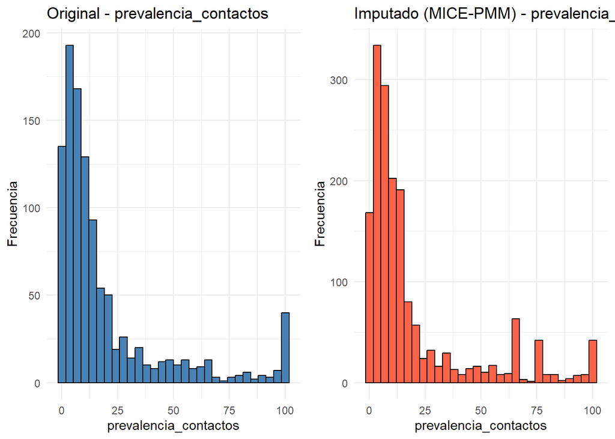

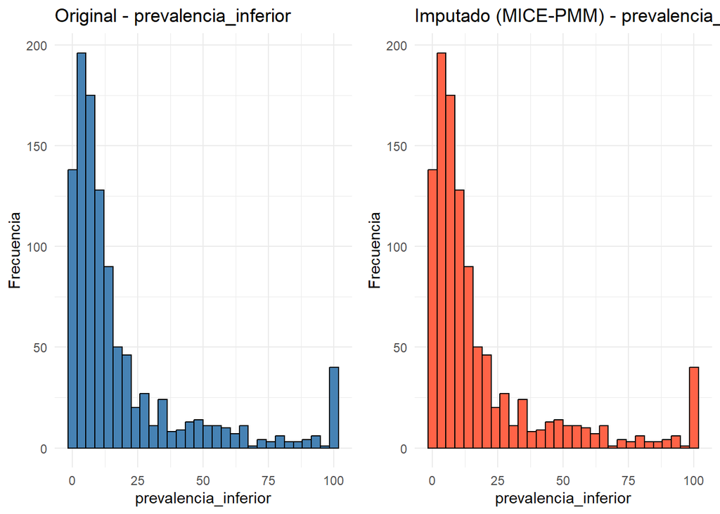

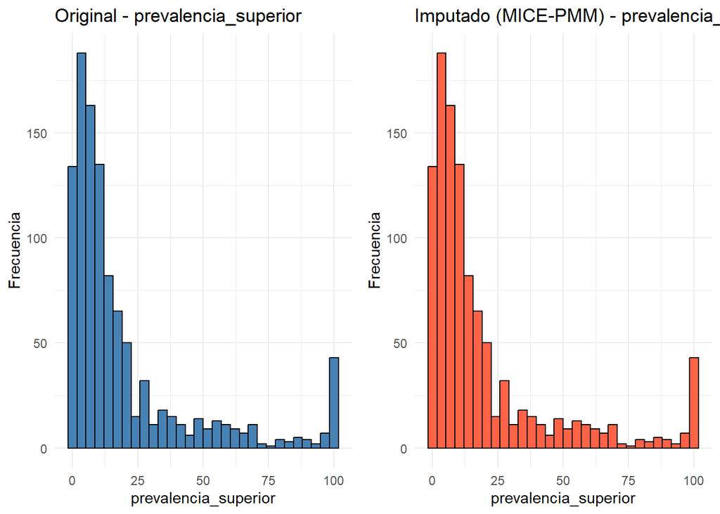

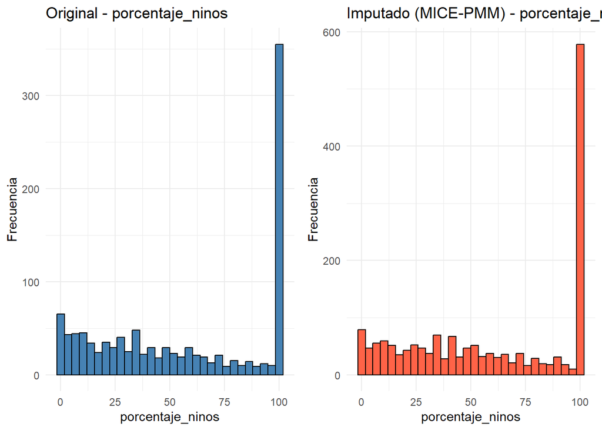

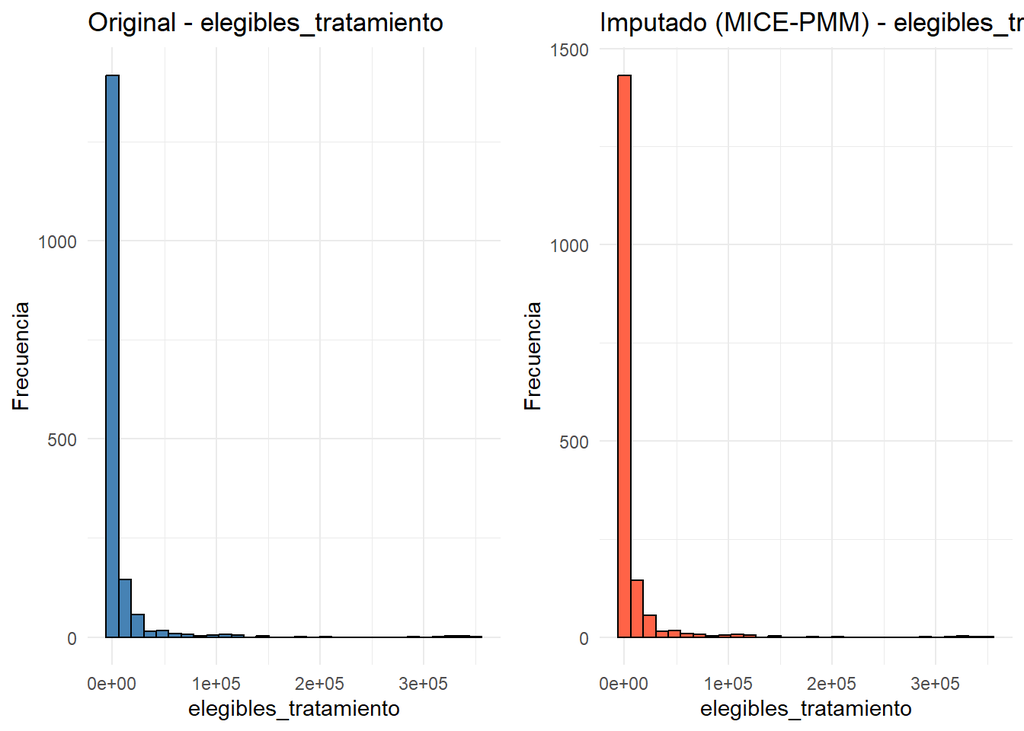

```r
vars_imputadas <- c("prevalencia_contactos",
                    "prevalencia_inferior",
                    "prevalencia_superior",
                    "porcentaje_ninos",
                    "elegibles_tratamiento")

graficos <- list()

for (var in vars_imputadas) {

  p1 <- ggplot(data, aes_string(x = var)) +
    geom_histogram(fill = "steelblue", color = "black", bins = 30) +
    ggtitle(paste("Original -", var)) +
    xlab(var) + ylab("Frecuencia") +
    theme_minimal()

  p2 <- ggplot(data_imputado2, aes_string(x = var)) +
    geom_histogram(fill = "tomato", color = "black", bins = 30) +
    ggtitle(paste("Imputado (MICE-PMM) -", var)) +
    xlab(var) + ylab("Frecuencia") +
    theme_minimal()

  graficos[[var]] <- gridExtra::grid.arrange(p1, p2, ncol = 2)
}
```

```r
invisible(graficos)
```

Como última medida se genera otro **missingness map** de este dataframe.

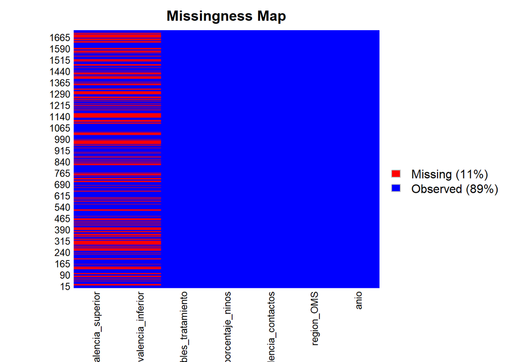

```r
missmap(data_imputado2, col = c("red", "blue"), legend = TRUE)
```

El gráfico arroja un **11%** de datos faltantes, distribuido entre **prevalencia_inferior** y **prevalencia_superior** que ya debían estar imputadas.

```r
porcentaje_na <- sapply(data_imputado2, function(x) sum(is.na(x)) / length(x) * 100)

tabla_na <- data.frame(
  Variable = names(porcentaje_na),
  Porcentaje_NA = round(porcentaje_na, 2)
)

tabla_na <- tabla_na[order(-tabla_na$Porcentaje_NA), ]

print(tabla_na)
```

```
##                                    Variable Porcentaje_NA
## prevalencia_inferior   prevalencia_inferior         37.43
## prevalencia_superior   prevalencia_superior         37.43
## anio                                   anio          0.00
## region_OMS                       region_OMS          0.00
## prevalencia_contactos prevalencia_contactos          0.00
## porcentaje_ninos           porcentaje_ninos          0.00
## elegibles_tratamiento elegibles_tratamiento          0.00
```

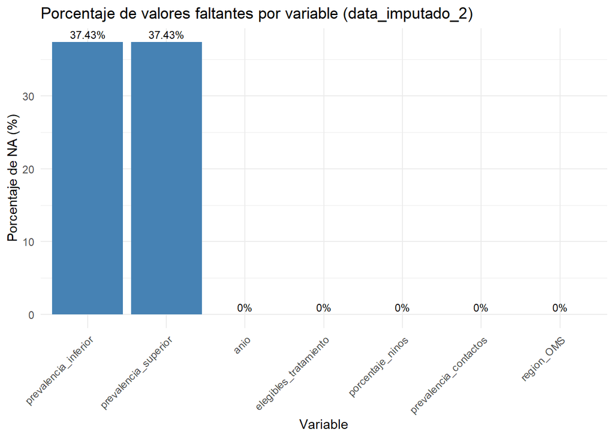

```r
ggplot(tabla_na, aes(x = reorder(Variable, -Porcentaje_NA), y = Porcentaje_NA)) +
  geom_bar(stat = "identity", fill = "steelblue") +
  geom_text(aes(label = paste0(Porcentaje_NA, "%")), vjust = -0.4, size = 3) +
  labs(
    title = "Porcentaje de valores faltantes por variable (data_imputado_2)",
    x = "Variable",
    y = "Porcentaje de NA (%)"
  ) +
  theme_minimal() +
  theme(axis.text.x = element_text(angle = 45, hjust = 1))
```

Esto significa que al imputar por **pmm** aunque se **conserva** la distribución de los datos, siguen existiendo valores **NA** en el dataframe.

### 2.5.5 Conclusión de la imputación

Aunque las pruebas estadísticas **(KS y Mann–Whitney)** sugieren una **posible alteración** en la forma de algunas distribuciones tras la imputación por **mediana**, este efecto no es relevante para el propósito del estudio, ya que no compromete la coherencia ni la escala original de los datos. En este caso, se privilegió la completitud y estabilidad del conjunto de datos por encima de la preservación exacta de la forma estadística, garantizando que todas las variables mantuvieran valores realistas y consistentes para el análisis descriptivo posterior

Por ende se conserva el dataframe imputado por la **mediana** con **0%** de valores **NA** y **con** una ligera distorsión en la distribución de las variables.

## 2.6 Detección de Outliers

## 2.7 Diagramas de caja y bigote

Como primera medida, se construirán varios **diagramas de caja y bigote** para las variables **numéricas** del dataframe.

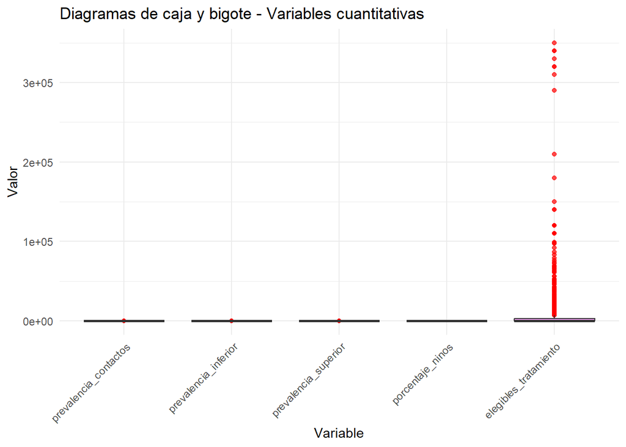

```r
num_vars <- data_imputado[, sapply(data_imputado, is.numeric)]
num_vars <- num_vars[, !names(num_vars) %in% "anio"]

num_melt <- melt(num_vars, variable.name = "Variable", value.name = "Valor")

ggplot(num_melt, aes(x = Variable, y = Valor, fill = Variable)) +
  geom_boxplot(outlier.color = "red", alpha = 0.7) +
  labs(
    title = "Diagramas de caja y bigote - Variables cuantitativas",
    x = "Variable",
    y = "Valor"
  ) +
  theme_minimal() +
  theme(
    axis.text.x = element_text(angle = 45, hjust = 1),
    legend.position = "none"
  )
```

Es evidente que todas las variables con excepción de **porcentaje_ninos**, tienen aparente presencia de **datos atípicos**. Sin embargoo es necesario aplicar otros métodos de detección para tener mayor seguridad.

### 2.7.1 Regla del rango intercuartílico (IQR)**

Se utiliza el método del rango intercuartílico con el fin de corroborar los resultados del inciso anterior.

```r
outliers_iqr <- function(x) {
  Q1 <- quantile(x, 0.25, na.rm = TRUE)
  Q3 <- quantile(x, 0.75, na.rm = TRUE)
  IQR <- Q3 - Q1
  lower <- Q1 - 1.5 * IQR
  upper <- Q3 + 1.5 * IQR
  sum(x < lower | x > upper, na.rm = TRUE)
}

num_vars <- data_imputado[, sapply(data_imputado, is.numeric)]
num_vars <- num_vars[, !names(num_vars) %in% "anio"]

sapply(num_vars, outliers_iqr)
```

```
## prevalencia_contactos  prevalencia_inferior  prevalencia_superior
##                    95                    98                    91
##      porcentaje_ninos elegibles_tratamiento
##                     0                   253
```

Los resultados obtenidos **concuerdan** con los obtenidos al analizar los **boxplots** graficados. Este método también arroja evidencia de posible presencia de datos atípicos en las mismas 4 variables que el anterior.

### 2.7.2 Modified Z-score

```r
modified_z_outliers <- function(x, threshold = 3.5) {
  med <- median(x, na.rm = TRUE)
  mad_val <- mad(x, constant = 1, na.rm = TRUE)
  M <- 0.6745 * (x - med) / mad_val
  sum(abs(M) > threshold, na.rm = TRUE)
}

num_vars <- data_imputado[, sapply(data_imputado, is.numeric)]
num_vars <- num_vars[, !names(num_vars) %in% "anio"]


sapply(num_vars, modified_z_outliers)
```

```
## prevalencia_contactos  prevalencia_inferior  prevalencia_superior
##                   186                   185                   145
##      porcentaje_ninos elegibles_tratamiento
##                     0                   556
```

Los resultados obtenidos no solo **concuerdan** con los anteriores, sino que esta vez reflejan una mayor detección de **outliers** en las 4 variables afectadas. Por lo que se tomará como principal indicador de valores atípicos en el dataframe.

## 2.8 Imputación de outliers

Se imputa por la **mediana**.

```r
imputar_outliers <- function(x, threshold = 3.5) {
  med <- median(x, na.rm = TRUE)
  mad_val <- mad(x, constant = 1, na.rm = TRUE)

  if (mad_val == 0 || is.na(mad_val)) return(x)

  M <- 0.6745 * (x - med) / mad_val
  x[abs(M) > threshold] <- med
  return(x)
}

contar_outliers <- function(df, threshold = 3.5) {
  sapply(df[, sapply(df, is.numeric)], function(x) {
    med <- median(x, na.rm = TRUE)
    mad_val <- mad(x, constant = 1, na.rm = TRUE)
    if (mad_val == 0 || is.na(mad_val)) return(0)
    M <- 0.6745 * (x - med) / mad_val
    sum(abs(M) > threshold, na.rm = TRUE)
  })
}

dataset_iter <- data_imputado

iter <- 1
repeat {
  outliers_restantes <- contar_outliers(dataset_iter)
  total_outliers <- sum(outliers_restantes)

  if (total_outliers == 0) break

  for (v in names(dataset_iter)) {
    if (is.numeric(dataset_iter[[v]]) && v != "anio") {
      dataset_iter[[v]] <- imputar_outliers(dataset_iter[[v]])
    }
  }

  iter <- iter + 1
}

data_final <- dataset_iter
```

## 2.9 Validación de la imputación

```r
modified_z_outliers <- function(x, threshold = 3.5) {
  med <- median(x, na.rm = TRUE)
  mad_val <- mad(x, constant = 1, na.rm = TRUE)
  M <- 0.6745 * (x - med) / mad_val
  sum(abs(M) > threshold, na.rm = TRUE)
}

num_vars <- data_final[, sapply(data_final, is.numeric)]
num_vars <- num_vars[, !names(num_vars) %in% "anio"]


sapply(num_vars, modified_z_outliers)
```

```
## prevalencia_contactos  prevalencia_inferior  prevalencia_superior
##                     0                     0                     0
##      porcentaje_ninos elegibles_tratamiento
##                     0                     0
```

Entonces, en efecto, se obtienen 0 **outliers**.

# 3 Resultados

En primer lugar, se construyó una **línea de tiempo** para observar cómo ha cambiado la prevalencia global de infección latente por tuberculosis (LTBI) en contactos domiciliarios entre los años más recientes del periodo disponible. Este gráfico permitirá identificar tendencias generales a lo largo del tiempo, como aumentos o reducciones sostenidas en la media global.

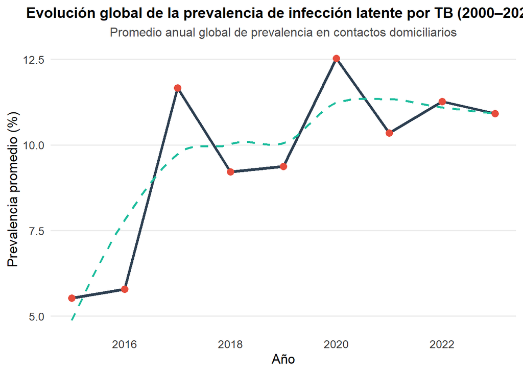

```r
evol_global <- data_final %>%
  group_by(anio) %>%
  summarise(media_prevalencia = mean(prevalencia_contactos, na.rm = TRUE))

ggplot(evol_global, aes(x = anio, y = media_prevalencia)) +
  geom_line(color = "#2C3E50", linewidth = 1.3) +
  geom_point(color = "#E74C3C", size = 3) +
  geom_smooth(method = "loess", se = FALSE, color = "#1ABC9C", linewidth = 1, linetype = "dashed") +
  labs(
    title = "Evolución global de la prevalencia de infección latente por TB (2000–2024)",
    subtitle = "Promedio anual global de prevalencia en contactos domiciliarios",
    x = "Año",
    y = "Prevalencia promedio (%)"
  ) +
  theme_minimal(base_size = 13) +
  theme(
    plot.title = element_text(face = "bold", size = 14, hjust = 0.5),
    plot.subtitle = element_text(size = 12, hjust = 0.5, color = "gray30"),
    axis.text = element_text(color = "gray20"),
    panel.grid.minor = element_blank(),
    panel.grid.major.x = element_blank()
  )
```

Ahora, para tener una visión más desagregada, se analizó la **tendencia temporal** de la prevalencia **por cada región de la OMS**. Esto ayuda a ver si el comportamiento global se repite en todas las zonas o si existen diferencias regionales importantes que podrían estar relacionadas con factores demográficos, económicos o con la calidad de los sistemas de vigilancia.

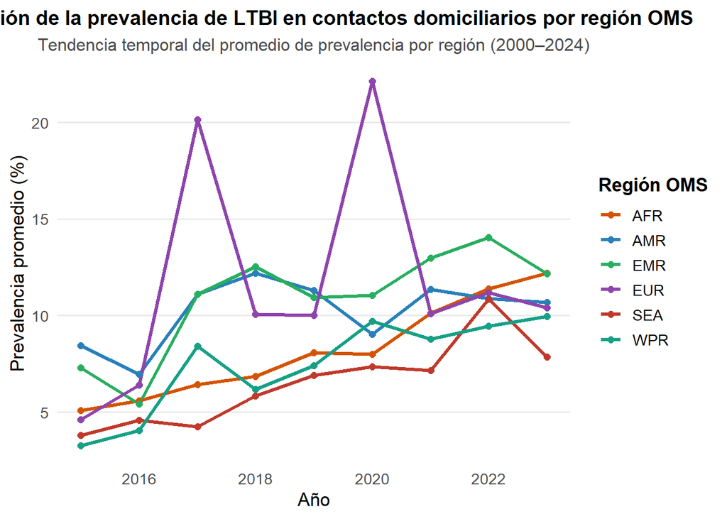

```r
evol_region <- data_final %>%
  group_by(region_OMS, anio) %>%
  summarise(media_prevalencia = mean(prevalencia_contactos, na.rm = TRUE))

colores_regiones <- c(
  "AFR" = "#D35400",
  "AMR" = "#2980B9",
  "EMR" = "#27AE60",
  "EUR" = "#8E44AD",
  "SEA" = "#C0392B",
  "WPR" = "#16A085"
)

ggplot(evol_region, aes(x = anio, y = media_prevalencia, color = region_OMS)) +
  geom_line(linewidth = 1.2) +
  geom_point(size = 2) +
  scale_color_manual(values = colores_regiones) +
  labs(
    title = "Evolución de la prevalencia de LTBI en contactos domiciliarios por región OMS",
    subtitle = "Tendencia temporal del promedio de prevalencia por región (2000–2024)",
    x = "Año",
    y = "Prevalencia promedio (%)",
    color = "Región OMS"
  ) +
  theme_minimal(base_size = 13) +
  theme(
    plot.title = element_text(face = "bold", size = 14, hjust = 0.5),
    plot.subtitle = element_text(size = 12, hjust = 0.5, color = "gray30"),
    legend.position = "right",
    legend.title = element_text(face = "bold"),
    panel.grid.minor = element_blank(),
    panel.grid.major.x = element_blank()
  )
```

Se realizó también, un **gráfico comparativo** con las **prevalencias promedio por región OMS para 2023**.

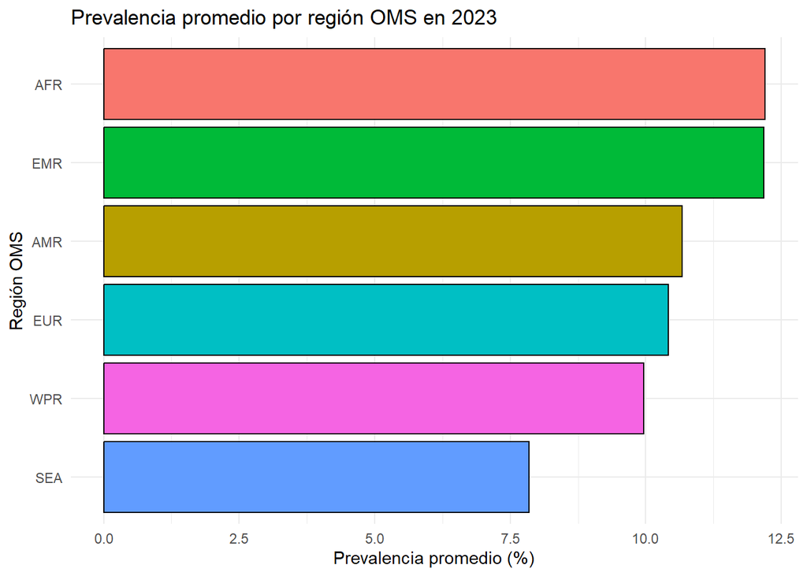

```r
ultimo_anio <- max(data_final$anio)

comparativo <- data_final %>%
  filter(anio == ultimo_anio) %>%
  group_by(region_OMS) %>%
  summarise(prevalencia_media = mean(prevalencia_contactos, na.rm = TRUE))

ggplot(comparativo, aes(x = reorder(region_OMS, prevalencia_media), y = prevalencia_media, fill = region_OMS)) +
  geom_bar(stat = "identity", color = "black") +
  coord_flip() +
  labs(
    title = paste("Prevalencia promedio por región OMS en", ultimo_anio),
    x = "Región OMS",
    y = "Prevalencia promedio (%)"
  ) +
  theme_minimal() +
  theme(legend.position = "none")
```

En 2023, las regiones **AFR y EMR** registran las prevalencias **más elevadas** (superiores al 12 %), mientras que **SEA** muestra los valores **más bajos**. Aunque las diferencias no son extremas, sí reflejan que la carga de infección sigue siendo desigual entre regiones. Las brechas observadas podrían estar asociadas a factores como la densidad poblacional, los programas de control de TB y la capacidad de diagnóstico de cada zona.

Para complementar el análisis de tendencias, se generó un **mapa de calor** que muestra la prevalencia promedio de infección latente por TB por región OMS y año.

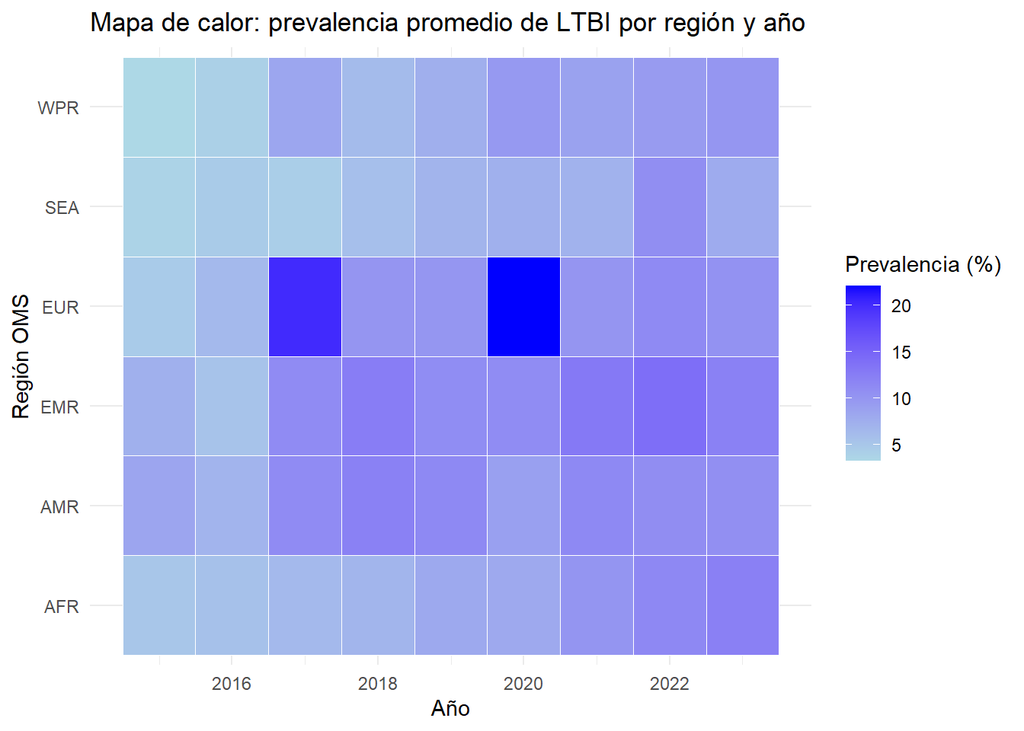

```r
heat_data <- data_final %>%
  group_by(region_OMS, anio) %>%
  summarise(media_prevalencia = mean(prevalencia_contactos, na.rm = TRUE))

ggplot(heat_data, aes(x = anio, y = region_OMS, fill = media_prevalencia)) +
  geom_tile(color = "white") +
  scale_fill_gradient(low = "lightblue", high = "blue") +
  labs(
    title = "Mapa de calor: prevalencia promedio de LTBI por región y año",
    x = "Año",
    y = "Región OMS",
    fill = "Prevalencia (%)"
  ) +
  theme_minimal()
```

A continuación, se presenta una comparación entre los valores inferior y superior de prevalencia por región OMS en el año más reciente disponible. Este gráfico sirve para visualizar el rango estimado dentro del cual se espera que fluctúe la verdadera prevalencia, evidenciando el nivel de variabilidad o incertidumbre asociado a cada región.

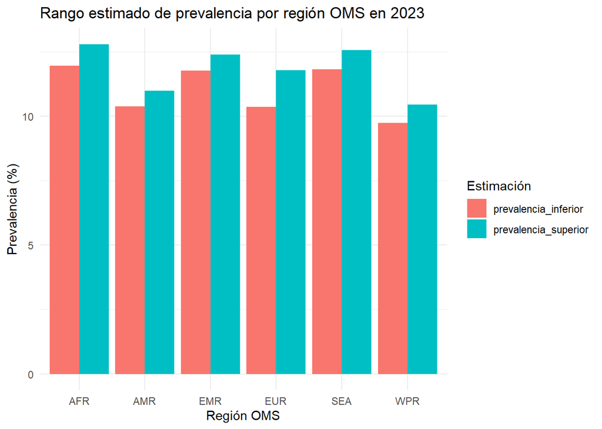

```r
ultimo_anio <- max(data_final$anio)

rango <- data_final %>%
  filter(anio == ultimo_anio) %>%
  group_by(region_OMS) %>%
  summarise(
    prevalencia_inferior = mean(prevalencia_inferior, na.rm = TRUE),
    prevalencia_superior = mean(prevalencia_superior, na.rm = TRUE)
  )

rango_largo <- rango %>%
  tidyr::pivot_longer(cols = c(prevalencia_inferior, prevalencia_superior),
                      names_to = "Tipo", values_to = "Valor")

ggplot(rango_largo, aes(x = region_OMS, y = Valor, fill = Tipo)) +
  geom_bar(stat = "identity", position = "dodge") +
  labs(
    title = paste("Rango estimado de prevalencia por región OMS en", ultimo_anio),
    x = "Región OMS",
    y = "Prevalencia (%)",
    fill = "Estimación"
  ) +
  theme_minimal()
```

# 4 Conclusión

Además, el análisis del rango de prevalencia muestra que algunas regiones presentan intervalos más amplios, lo cual sugiere mayor incertidumbre en las estimaciones o variabilidad entre países.

En general, el estudio evidencia que la tuberculosis latente sigue siendo un problema persistente de salud pública global, con progresos limitados en la reducción de su prevalencia, especialmente en regiones donde la carga sigue siendo alta y desigual.